# Ford Go Bike Dataset Exploration

## by Steven John

## Investigation Overview

- Ford Go bike services offers rental services for bikes.
- Our overall goals for this presentation could be divided into 3 main points which are:

  When is the busiest time for the rental services? according to weekend or weekdays, hour, user type and which user type uses the rental services more?

  What is the average ride duration and which user type and gender enjoys longer rides and on what day?

  What are the top three busiest start and end stations? Least three busiest start and end stations?

## When is the busiest time for the rental services? according to weekend or weekdays, hour, user type and which user type uses the rental services more?

### From our visulization we have surmized that:

- In general the busiest time for the rental service will be on weekdays especially on Tuesday and Thursday at 8 am and 5 pm.
- For user type customers, the busiest time wil be on Thursday at 5pm. and Friday at 8 am.
- For user type Subscriber, the busiest time wil be on Tuesday and Thursday at 8 am.
- About 90 % of the rental services users are Subscribers.

### Conclusion:

- We can estimate that users mostly use the rental service to commute to thier jobs during the weekdays as the start hours also corosponds with normal office hours

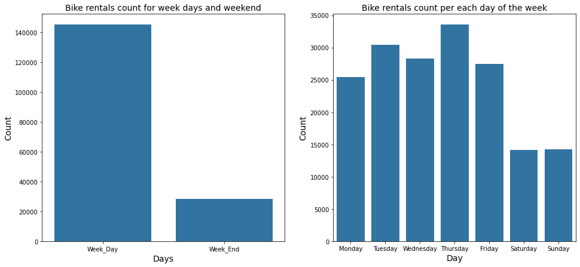

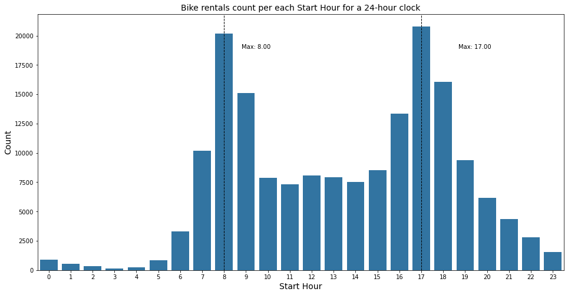

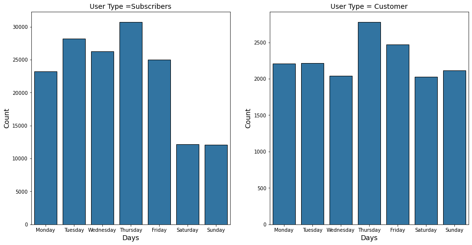

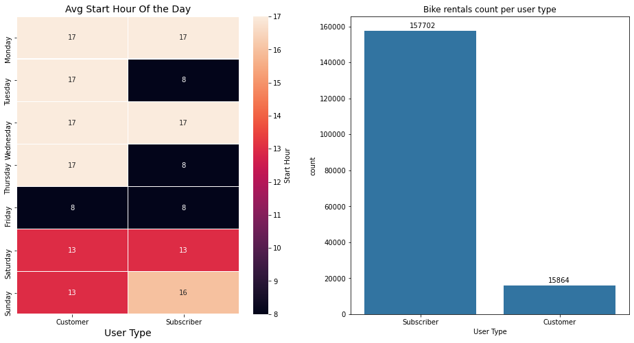

## What are the average ride duration and which user type and gender enjoys longer rides and on what day?

Note: we ablied logarithmic scale on the histogram of the rides per duration in mins because most data was right skewed.

### From our visulization we have surmized that:

- The average ride duration is betwen 8 min to 10 min In general.
- user type customers seem to enjoy longer ride duration and especially on weekends with an average duration of 17 min while the sibscribers had an average duration of 10 min on Saturday and Sunday
- user type customer and gender female enjoy the longest ride with avg duration of about 16 mins.

### Conclusion:

- I guess the users in general like to enjoy longer rider on thier day off especially user type customers who are female.

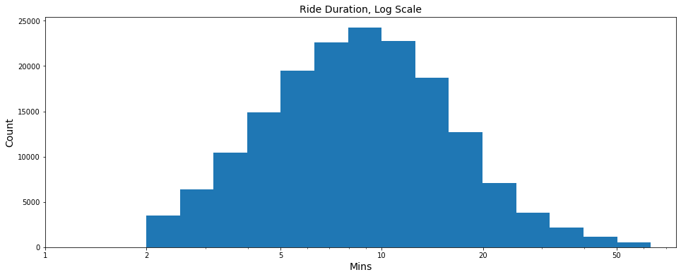

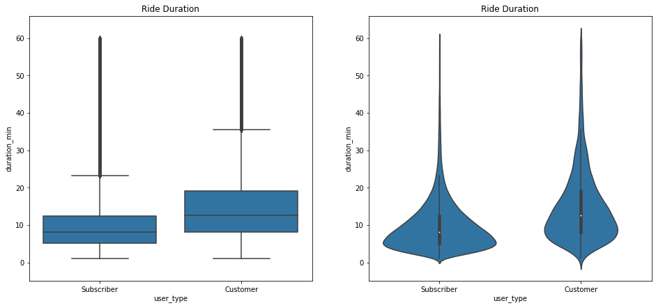

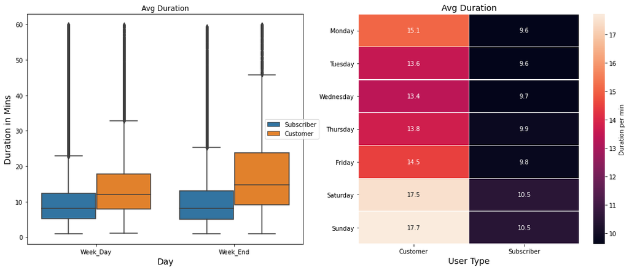

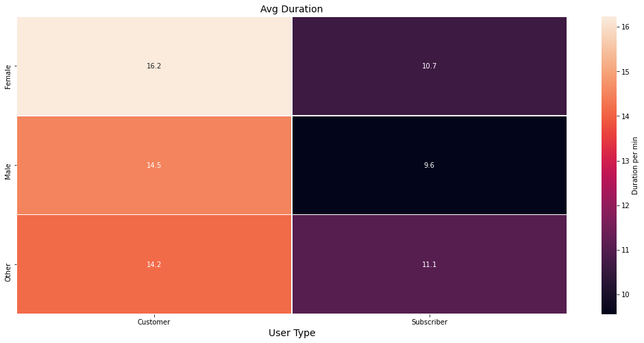

## What are the top three busiest start and end stations? Least three busiest start and end stations?

### From our visulization we have surmized that:

- The Top three busiest start stations are 'Market St at 10th St', 'San Francisco Caltrain Station 2 (Townsend St at 4th St)' and 'Berry St at 4th St'
- Top Three busiest end stations are 'San Francisco Caltrain Station 2 (Townsend St at 4th St)','Market St at 10th St' and 'Montgomery St BART Station (Market St at 2nd St)'
- the Lowest three busiest start stations are '16th St Depot', 'Palm St at Willow St'and '21st Ave at International Blvd'
- the Lowest three busiest end stations are '16th St Depot', 'Willow St at Vine St' and '21st Ave at International Blvd'

### Conclusion:

- The top three busiest start stations provide rental serivce for about 5% and top three busiest end station provide rental serivce for about 6% while the lowest three busiest stations both end and start stations combiend provides rental service for merley about 0.01% out of 329 stations

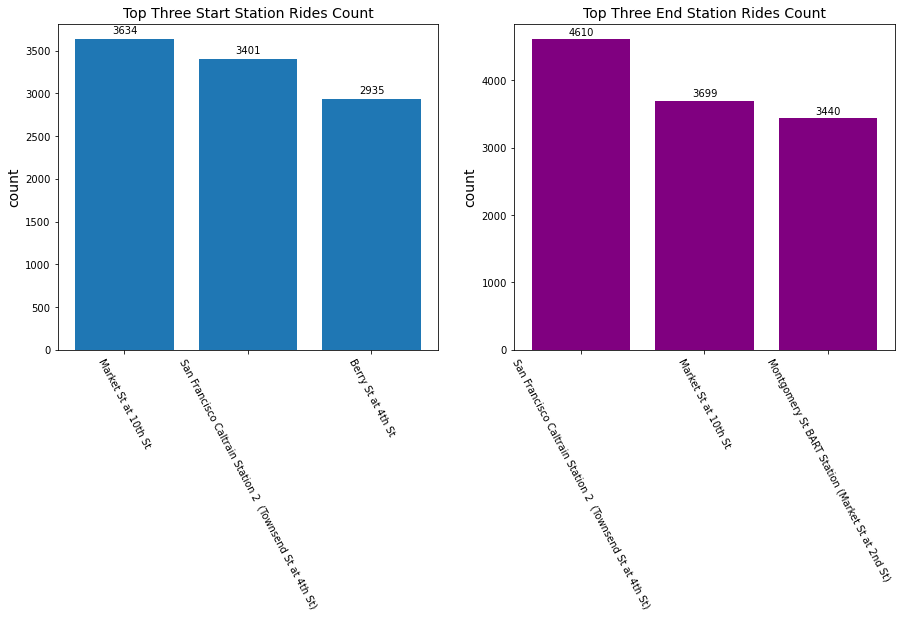

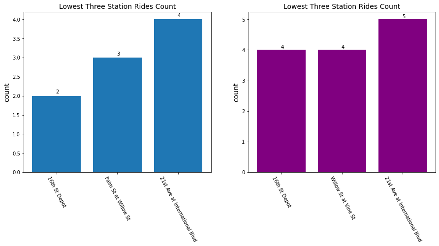